# Background

My friend is interested in acquiring an apartment building in particular locations like Humboldt Park, Lincoln Park, Logan Square, and West Town areas. I want to help by predicting prices, so I can tell him if properties are good deals or not. He gave me some information with 2-4 Unit and 5+ Unit apartment buildings in areas he wants to acquire. The given dataset has 27 variables and 125 observations.

# Data Preparation/Cleaning

```python
import seaborn as sns
import numpy as np
import matplotlib.pyplot as plt
import pandas as pd
%matplotlib inline
```

```python
df = pd.read_csv('properties.csv')
```

```python
df.head()
```

|  | SALE TYPE | SOLD DATE | PROPERTY TYPE | ADDRESS | CITY | STATE | ZIP | PRICE | BEDS | BATHS | ... | STATUS | NEXT OPEN HOUSE START TIME | NEXT OPEN HOUSE END TIME | URL | SOURCE | MLS# | FAVORITE | INTERESTED | LATITUDE | LONGITUDE |
| --- | --- | --- | --- | --- | --- | --- | --- | --- | --- | --- | --- | --- | --- | --- | --- | --- | --- | --- | --- | --- | --- |
| 0 | MLS Listing | NaN | Multi-Family (5+ Unit) | 1843 W Thomas St | CHICAGO | IL | 60622 | 1699000 | 37 | 24.0 | ... | Active | NaN | NaN | http://www.redfin.com/IL/Chicago/1843-W-Thomas... | MRED | 10133801 | N | Y | 41.901249 | -87.674025 |
| 1 | MLS Listing | NaN | Multi-Family (5+ Unit) | 2027 N SHEFFIELD Ave | CHICAGO | IL | 60614 | 1495000 | 27 | 21.0 | ... | Active | NaN | NaN | http://www.redfin.com/IL/Chicago/2027-N-Sheffi... | MRED | 10135551 | N | Y | 41.918939 | -87.653123 |
| 2 | MLS Listing | NaN | Multi-Family (2-4 Unit) | 834 N Mozart St | CHICAGO | IL | 60622 | 449900 | 8 | 4.0 | ... | Active | NaN | NaN | http://www.redfin.com/IL/Chicago/834-N-Mozart-... | MRED | 10139661 | N | Y | 41.896717 | -87.698266 |
| 3 | MLS Listing | NaN | Multi-Family (2-4 Unit) | 867 N Richmond St | CHICAGO | IL | 60622 | 418900 | 7 | 2.0 | ... | Active | NaN | NaN | http://www.redfin.com/IL/Chicago/867-N-Richmon... | MRED | 10116300 | N | Y | 41.897491 | -87.700153 |
| 4 | MLS Listing | NaN | Multi-Family (2-4 Unit) | 1753 W Superior St | CHICAGO | IL | 60622 | 549000 | 8 | 3.0 | ... | Active | NaN | NaN | http://www.redfin.com/IL/Chicago/1753-W-Superi... | MRED | 10123659 | N | Y | 41.894910 | -87.671813 |

5 rows × 27 columns

```python
df.shape
```

```
(125, 27)
```

We can see from the upcoming heatmap that some of the columns entirely lost. We can drop them; we also may toss out columns that only have text information; they will be hard to interpret for our future model.

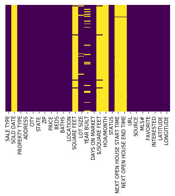

```python
sns.heatmap(df.isnull(),yticklabels=False,cbar=False,cmap='viridis')
```

```python
df.columns
```

```
Index(['SALE TYPE', 'SOLD DATE', 'PROPERTY TYPE', 'ADDRESS', 'CITY', 'STATE',
       'ZIP', 'PRICE', 'BEDS', 'BATHS', 'LOCATION', 'SQUARE FEET', 'LOT SIZE',
       'YEAR BUILT', 'DAYS ON MARKET', '$/SQUARE FEET', 'HOA/MONTH', 'STATUS',
       'NEXT OPEN HOUSE START TIME', 'NEXT OPEN HOUSE END TIME', 'URL',
       'SOURCE', 'MLS#', 'FAVORITE', 'INTERESTED', 'LATITUDE', 'LONGITUDE'],
      dtype='object')
```

```python
df.drop(['SOLD DATE','SQUARE FEET','$/SQUARE FEET','HOA/MONTH',
        'NEXT OPEN HOUSE END TIME','NEXT OPEN HOUSE END TIME',
        'URL','SOURCE', 'MLS#', 'LATITUDE', 'LONGITUDE', 'FAVORITE',
             'STATUS','NEXT OPEN HOUSE START TIME','INTERESTED',
             'ADDRESS','CITY', 'STATE','ZIP'], axis=1, inplace=True)
```

```python
df.head()
```

|  | SALE TYPE | PROPERTY TYPE | PRICE | BEDS | BATHS | LOCATION | LOT SIZE | YEAR BUILT | DAYS ON MARKET |
| --- | --- | --- | --- | --- | --- | --- | --- | --- | --- |
| 0 | MLS Listing | Multi-Family (5+ Unit) | 1699000 | 37 | 24.0 | West Town | 2613.0 | 1889.0 | 13 |
| 1 | MLS Listing | Multi-Family (5+ Unit) | 1495000 | 27 | 21.0 | Lincoln Park | NaN | 1888.0 | 10 |
| 2 | MLS Listing | Multi-Family (2-4 Unit) | 449900 | 8 | 4.0 | West Town | 3000.0 | 1883.0 | 6 |
| 3 | MLS Listing | Multi-Family (2-4 Unit) | 418900 | 7 | 2.0 | West Town | 3484.0 | 1905.0 | 35 |
| 4 | MLS Listing | Multi-Family (2-4 Unit) | 549000 | 8 | 3.0 | West Town | 2613.0 | 1905.0 | 26 |

```python
df.shape
```

```
(125, 9)
```

For the sake of readability when we will be doing our further analysis, I renamed all the columns.

```python
df = df.rename(columns={'SALE TYPE':'SALE_TYPE','PROPERTY TYPE':'PROPERTY_TYPE','LOT SIZE':'LOT_SIZE',
                   'YEAR BUILT':'YEAR_BUILT','DAYS ON MARKET':'DAYS_ON_MARKET'})
```

```python
df.head()
```

|  | SALE_TYPE | PROPERTY_TYPE | PRICE | BEDS | BATHS | LOCATION | LOT_SIZE | YEAR_BUILT | DAYS_ON_MARKET |
| --- | --- | --- | --- | --- | --- | --- | --- | --- | --- |
| 0 | MLS Listing | Multi-Family (5+ Unit) | 1699000 | 37 | 24.0 | West Town | 2613.0 | 1889.0 | 13 |
| 1 | MLS Listing | Multi-Family (5+ Unit) | 1495000 | 27 | 21.0 | Lincoln Park | NaN | 1888.0 | 10 |
| 2 | MLS Listing | Multi-Family (2-4 Unit) | 449900 | 8 | 4.0 | West Town | 3000.0 | 1883.0 | 6 |
| 3 | MLS Listing | Multi-Family (2-4 Unit) | 418900 | 7 | 2.0 | West Town | 3484.0 | 1905.0 | 35 |
| 4 | MLS Listing | Multi-Family (2-4 Unit) | 549000 | 8 | 3.0 | West Town | 2613.0 | 1905.0 | 26 |

```python
df.info()
```

```
<class 'pandas.core.frame.DataFrame'>
RangeIndex: 125 entries, 0 to 124
Data columns (total 9 columns):
SALE_TYPE         125 non-null object
PROPERTY_TYPE     125 non-null object
PRICE             125 non-null int64
BEDS              125 non-null int64
BATHS             125 non-null float64
LOCATION          125 non-null object
LOT_SIZE          120 non-null float64
YEAR_BUILT        109 non-null float64
DAYS_ON_MARKET    125 non-null int64
dtypes: float64(3), int64(3), object(3)
memory usage: 8.9+ KB
```

```python
df.columns
```

```
Index(['SALE_TYPE', 'PROPERTY_TYPE', 'PRICE', 'BEDS', 'BATHS', 'LOCATION',
       'LOT_SIZE', 'YEAR_BUILT', 'DAYS_ON_MARKET'],
      dtype='object')
```

We need to prepare our dataset for the machine learning process. For that, first I decided to turn our object values into dummies.

```python
for column in ['SALE_TYPE', 'PROPERTY_TYPE', 'LOCATION']:
    print(df[column].unique())
    dummies = pd.get_dummies(df[column],prefix=column).iloc[:,1:]
    df = pd.concat([df, dummies],axis=1)
```

```
['MLS Listing' 'For-Sale-by-Owner Listing']
['Multi-Family (5+ Unit)' 'Multi-Family (2-4 Unit)']
['West Town' 'Lincoln Park' 'Logan Square' 'Humboldt Park' 'Chicago']
```

Since we will be using only integers in our machine learning process, we can get rid of the columns we turned into dummies. In our case, we will drop three columns.

```python
df.drop(['SALE_TYPE', 'PROPERTY_TYPE', 'LOCATION'], axis=1, inplace=True)
```

We also notice that the LOT_SIZE and YEAR_BUILT columns have some missing values and we need to fill them.

```python
df.isnull().sum()
```

```
PRICE                                    0
BEDS                                     0
BATHS                                    0
LOT_SIZE                                 5
YEAR_BUILT                              16
DAYS_ON_MARKET                           0
SALE_TYPE_MLS Listing                    0
PROPERTY_TYPE_Multi-Family (5+ Unit)     0
LOCATION_Humboldt Park                   0
LOCATION_Lincoln Park                    0
LOCATION_Logan Square                    0
LOCATION_West Town                       0
dtype: int64
```

If I drop the rows with missing values, I might end up losing valuable data. Since we don't have abundant observations, it would be better to try to keep as much data as we can.

```python
df[['YEAR_BUILT', 'LOT_SIZE']].median()
```

```
YEAR_BUILT    1892.0
LOT_SIZE      3049.0
dtype: float64
```

```python
df[['YEAR_BUILT', 'LOT_SIZE']]= df[['YEAR_BUILT', 'LOT_SIZE']].fillna(df[['YEAR_BUILT', 'LOT_SIZE']].median())
```

```
(125, 12)
```

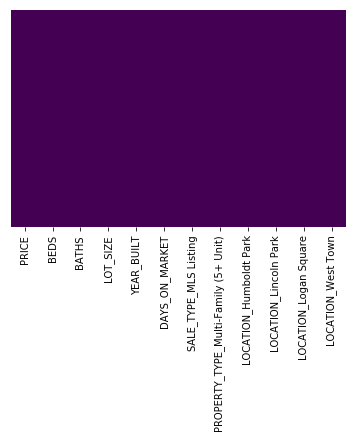

```python
sns.heatmap(df.isnull(),yticklabels=False,cbar=False,cmap='viridis')
df.shape
```

Now we left with clean dataset for our future exploration.

```python
df.head()
```

|  | PRICE | BEDS | BATHS | LOT_SIZE | YEAR_BUILT | DAYS_ON_MARKET | SALE_TYPE_MLS Listing | PROPERTY_TYPE_Multi-Family (5+ Unit) | LOCATION_Humboldt Park | LOCATION_Lincoln Park | LOCATION_Logan Square | LOCATION_West Town |
| --- | --- | --- | --- | --- | --- | --- | --- | --- | --- | --- | --- | --- |
| 0 | 1699000 | 37 | 24.0 | 2613.0 | 1889.0 | 13 | 1 | 1 | 0 | 0 | 0 | 1 |
| 1 | 1495000 | 27 | 21.0 | 3049.0 | 1888.0 | 10 | 1 | 1 | 0 | 1 | 0 | 0 |
| 2 | 449900 | 8 | 4.0 | 3000.0 | 1883.0 | 6 | 1 | 0 | 0 | 0 | 0 | 1 |
| 3 | 418900 | 7 | 2.0 | 3484.0 | 1905.0 | 35 | 1 | 0 | 0 | 0 | 0 | 1 |
| 4 | 549000 | 8 | 3.0 | 2613.0 | 1905.0 | 26 | 1 | 0 | 0 | 0 | 0 | 1 |

## Data Visualization

We see from the next plot that 'BEDS', 'BATHS' variables are strongly correlated with PRICE.

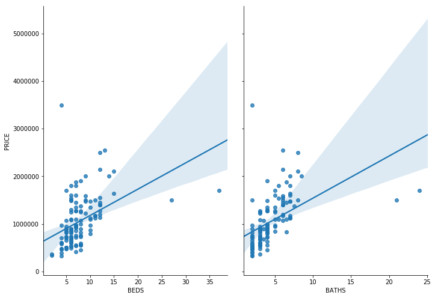

```python
sns.pairplot(df, x_vars=['BEDS', 'BATHS'], y_vars='PRICE', size=7, aspect=0.7, kind='reg')
```

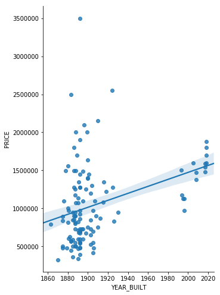

```python
sns.pairplot(df, x_vars=['YEAR_BUILT'], y_vars='PRICE', size=7, aspect=0.7, kind='reg')
```

This seems a little odd, and normally I would check with my friend to see if this data is incomplete. But for the sake of the exercise, I won't dig into it.

When we wanted to assess the correlation between LOT_SIZE and PRICE we see something strange happens. Let's find out.

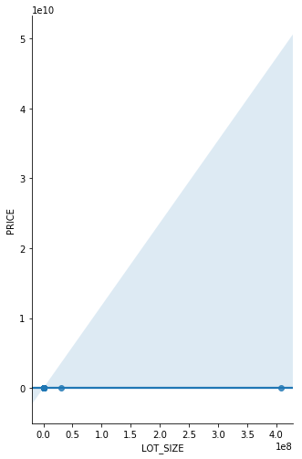

```python
sns.pairplot(df, x_vars=['LOT_SIZE'], y_vars='PRICE', size=7, aspect=0.7, kind='reg')
```

I decided to check the distribution of our LOT_SIZE by making a seaborn plot.

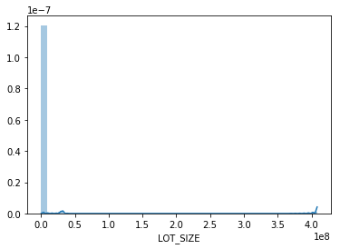

```python
sns.distplot(df["LOT_SIZE"])
```

The chart above shows that one of the houses is 400 million square feet, which is too large to be correct. Wikipedia indicates that the largest homes in the world are only about 200,000 square feet.

Normally, I would check in with the data owner to understand more about why this value would appear, but in this case, I decided to proceed with the analysis after removing properties with LOT_SIZE values that were obviously too large (e.g. over 200000 square feet).

```python
df.loc[df.LOT_SIZE>200000]
```

|  | PRICE | BEDS | BATHS | LOT_SIZE | YEAR_BUILT | DAYS_ON_MARKET | SALE_TYPE_MLS Listing | PROPERTY_TYPE_Multi-Family (5+ Unit) | LOCATION_Humboldt Park | LOCATION_Lincoln Park | LOCATION_Logan Square | LOCATION_West Town |
| --- | --- | --- | --- | --- | --- | --- | --- | --- | --- | --- | --- | --- |
| 35 | 1175000 | 11 | 6.0 | 30714156.0 | 1887.0 | 13 | 1 | 1 | 0 | 0 | 0 | 1 |
| 114 | 1899000 | 8 | 4.0 | 408375000.0 | 1892.0 | 51 | 1 | 0 | 0 | 0 | 1 | 0 |

If we exclude these found bad data, we can see the improvement in our distribution.

```python
df = df.loc[df.LOT_SIZE<200000]
```

```python
df.shape
```

```
(123, 12)
```

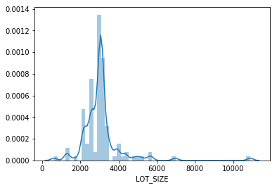

```python
sns.distplot(df.loc[df["LOT_SIZE"] < 300000, "LOT_SIZE"])
```

The line still doesn't seem to follow the dots as closely as you'd expect, and it's probably because of that significant outlier on the right.

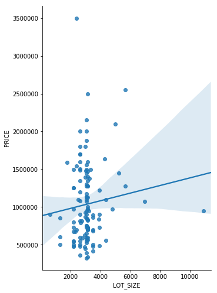

```python
sns.pairplot(df, x_vars=['LOT_SIZE'], y_vars='PRICE', size=7, aspect=0.7, kind='reg')
```

Also, a one might expect a price decrease, on the properties, have been held on the market for a long time; we can see from our plot that this is not an attribute that affects the price much. I can think of that as an unwillingness of the property owner's to bend the price under the given amount. However, using an agent's service and getting a 5+ Unit Multi-Family properties indeed affect the price.

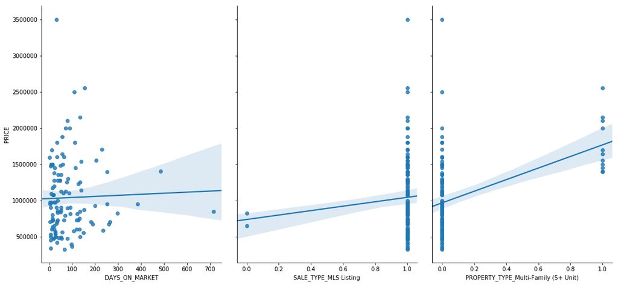

```python
sns.pairplot(df, x_vars=['DAYS_ON_MARKET','SALE_TYPE_MLS Listing', 'PROPERTY_TYPE_Multi-Family (5+ Unit)'], y_vars='PRICE', size=7, aspect=0.7, kind='reg')
```

Let's analyze the effect of locations on our price.

```python
df.head()
```

|  | PRICE | BEDS | BATHS | LOT_SIZE | YEAR_BUILT | DAYS_ON_MARKET | SALE_TYPE_MLS Listing | PROPERTY_TYPE_Multi-Family (5+ Unit) | LOCATION_Humboldt Park | LOCATION_Lincoln Park | LOCATION_Logan Square | LOCATION_West Town |
| --- | --- | --- | --- | --- | --- | --- | --- | --- | --- | --- | --- | --- |
| 0 | 1699000 | 37 | 24.0 | 2613.0 | 1889.0 | 13 | 1 | 1 | 0 | 0 | 0 | 1 |
| 1 | 1495000 | 27 | 21.0 | 3049.0 | 1888.0 | 10 | 1 | 1 | 0 | 1 | 0 | 0 |
| 2 | 449900 | 8 | 4.0 | 3000.0 | 1883.0 | 6 | 1 | 0 | 0 | 0 | 0 | 1 |
| 3 | 418900 | 7 | 2.0 | 3484.0 | 1905.0 | 35 | 1 | 0 | 0 | 0 | 0 | 1 |
| 4 | 549000 | 8 | 3.0 | 2613.0 | 1905.0 | 26 | 1 | 0 | 0 | 0 | 0 | 1 |

```python
df[['LOCATION_Humboldt Park', 'LOCATION_Lincoln Park',
       'LOCATION_Logan Square', 'LOCATION_West Town']].idxmax(axis=1).head()
```

```
0       LOCATION_West Town
1    LOCATION_Lincoln Park
2       LOCATION_West Town
3       LOCATION_West Town
4       LOCATION_West Town
dtype: object
```

From our violin plot, we see the highest medium price falls into a Lincoln Park location range and the least expensive into a Humboldt Park.

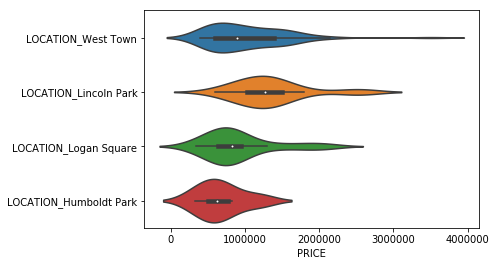

```python
sns.violinplot(y=df[['LOCATION_Humboldt Park', 'LOCATION_Lincoln Park',
       'LOCATION_Logan Square', 'LOCATION_West Town']].idxmax(axis=1), x=df['PRICE'], orient='h')
```

From our distribution plot below, we notice that no one is selling cheap houses and a few houses that are over $2,000,000.

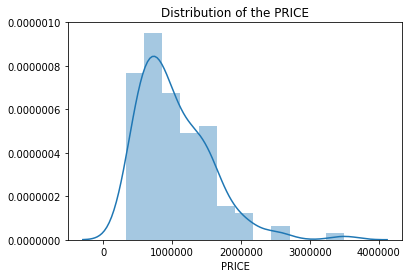

```python
sns.distplot([df['PRICE']])
plt.xlabel('PRICE')
plt.title('Distribution of the PRICE')
```

# Machine Learning (Random Forest regression)

I will use a Random Forest Regressor since the target variable is a continuous real number.

```python
from sklearn.ensemble import RandomForestRegressor
from sklearn.model_selection import train_test_split
```

```python
X = df.drop('PRICE',axis=1)
y = df['PRICE']
X_train, X_test, y_train, y_test = train_test_split(X, y, test_size=0.2, random_state=42)
```

```python
print(X_train.shape)
print(y_train.shape)
```

```
(98, 11)
(98,)
```

```python
print(X_test.shape)
print(y_test.shape)
```

```
(25, 11)
(25,)
```

```python
model = RandomForestRegressor()
model.fit(X_train, y_train)
```

```
RandomForestRegressor(bootstrap=True, criterion='mse', max_depth=None,
           max_features='auto', max_leaf_nodes=None,
           min_impurity_decrease=0.0, min_impurity_split=None,
           min_samples_leaf=1, min_samples_split=2,
           min_weight_fraction_leaf=0.0, n_estimators=10, n_jobs=1,
           oob_score=False, random_state=None, verbose=0, warm_start=False)
```

```python
y_pred = model.predict(X_test)
```

From here we can build our plot and add the prediction line.

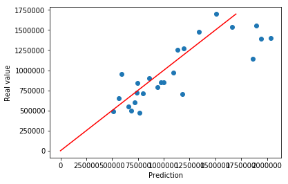

```python
plt.scatter(y_pred, y_test)
plt.xlabel('Prediction')
plt.ylabel('Real value')

diagonal = np.linspace(0, np.max(y_test), 100)
plt.plot(diagonal, diagonal, '-r')
plt.show()
```

```python
from sklearn.metrics import mean_squared_log_error, mean_absolute_error

print('MAE:\t$%.2f' % mean_absolute_error(y_test, y_pred))
print('MSLE:\t%.5f' % mean_squared_log_error(y_test, y_pred))
```

```
MAE:	$213688.20
MSLE:	0.06471
```

From the table below we can evaluate the importance of our features.

```python
feature_evaluation = pd.DataFrame(100*model.feature_importances_,X.columns).sort_values(by=0, ascending=False)
feature_evaluation.columns = ['feature_importance']
feature_evaluation
```

|  | feature_importance |
| --- | --- |
| BATHS | 42.330296 |
| DAYS_ON_MARKET | 13.807564 |
| BEDS | 13.665415 |
| YEAR_BUILT | 12.507038 |
| LOT_SIZE | 10.881776 |
| LOCATION_Lincoln Park | 5.495590 |
| LOCATION_West Town | 0.828928 |
| LOCATION_Logan Square | 0.230226 |
| LOCATION_Humboldt Park | 0.218213 |
| PROPERTY_TYPE_Multi-Family (5+ Unit) | 0.034954 |
| SALE_TYPE_MLS Listing | 0.000000 |

# Linear Regression

Let's try a Linear Regression model and compare it with RF.

```python
from sklearn.linear_model import LinearRegression

reg = LinearRegression()
reg.fit(X_train, y_train)
lin_pred = reg.predict(X_test)
```

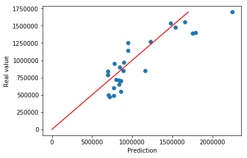

```python
plt.scatter(lin_pred, y_test)
plt.xlabel('Prediction')
plt.ylabel('Real value')

diagonal = np.linspace(0, np.max(y_test), 100)
plt.plot(diagonal, diagonal, '-r')
plt.show()
```

```python
print('MAE:\t$%.2f' % mean_absolute_error(y_test, lin_pred))
print('MSLE:\t%.5f' % mean_squared_log_error(y_test, lin_pred))
```

```
MAE:	$188805.56
MSLE:	0.05741
```

A deviation of $188805.56,- which is mainly due to the extreme outliers.

We can evaluate the coefficients of each feature as well.

```python
coefficients = pd.DataFrame(reg.coef_,X_train.columns).sort_values(by=0,ascending=False)
coefficients.columns = ['coefficients']
coefficients
```

|  | coefficients |
| --- | --- |
| PROPERTY_TYPE_Multi-Family (5+ Unit) | 788064.963163 |
| LOCATION_Lincoln Park | 316839.030756 |
| SALE_TYPE_MLS Listing | 45354.795936 |
| BATHS | 44871.616201 |
| YEAR_BUILT | 4622.630683 |
| DAYS_ON_MARKET | 145.715424 |
| LOT_SIZE | -6.985470 |
| BEDS | -9278.229730 |
| LOCATION_West Town | -55198.915710 |
| LOCATION_Logan Square | -102332.034740 |
| LOCATION_Humboldt Park | -113953.284370 |

# Conclusion

We can see some coefficient discrepancies in both algorithms. There are some clear outliers in the dataset that we are predicting very badly, so it would be a good idea to understand why we're so far off with those.

Housing prices are correlated with location. With neighborhoods like Lincoln Park, it's far more expensive on average than neighborhoods like Humboldt Park. It's also apparent that the type and age of the property affect the price as well. 5+ Unit type properties cost more expensive compared to 2-4 Unit. If the data were available, it could be illuminating to analyze the impact of features like the presence or absence of a garage or porch, the overall condition of the house, air quality and safety of the neighborhood and so on.